# Project 1 Writeup

Jenna Tan

# Introduction

Booking travel accomodations is one of the most important part of planning a vacation and oftentimes, it is the most expensive part of your travel budget.

In this analysis, I break down a dataset containing listings of Airbnb properties in Asheville, NC to determine what characteristics predict the price of a listing. I will then create a predictive model to determine if I’m being overcharged for the listing I chose to use for my honeymoon.

# Dataset Description

This dataset was sourced from InsideAirbnb.com and was last updated on June 25, 2020. It contains 2,407 different listings with 106 points of data on each property. Examples of included properties are superhost status, price, bedrooms, zipcode, and rating.

# Exploration

I first explore my outcome variable, price. Price is represented in multiple ways in the dataset including nightly price, weekly price and monthly price. I decided to look at the price for a one-night stay, including the cleaning fee. Thus, the usage of “price” in this analysis represents the sum of rent for one night and the cleaning fee. I chose to exclude taxes and other fees since it would vary from property to property.

Since the goal of my analysis is to create a model that can be used to predict prices as I browse Airbnb, I am limited to predictors that can be determined based on the listing page alone. Predictors that are available in the dataset and the listing page is the property type, the room type, the number of bathrooms, the number of bedrooms, the number of beds, the average score of reviews, and the superhost status of the host.

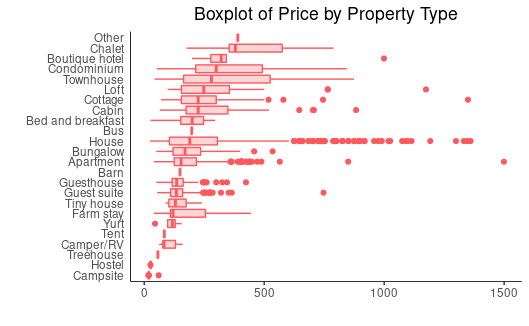

**Figure 2**: The figure shows the spread of price by property type. Note that houses have a large number of outliers.

Due to the great variation in price by property type demonstrated in the boxplots, I decided to narrow my analysis to a smaller scope and only examined types of properties that we would potentially book: condominiums, townhomes, houses, and apartments.

# Investigation of Outliers in House

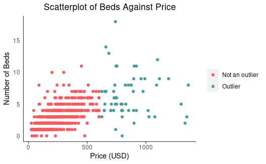

# Analysis Dataset

After limiting the dataset to relevant property types and to the predictors we are interested in, the data now has 1,419 complete cases for us to predict and test on.

We split the data about 50/50 to create testing and training datasets using a seed of 1107.

# Best subset selection

```r
regfit.best=regsubsets(total_price~.,train,nvmax=9)
test.mat=model.matrix(total_price~.,test)
val.errors=rep(NA,5)
for(i in 1:5) {
  coefi=coef(regfit.best,id=i)
  pred=test.mat[,names(coefi)]%*%coefi
  val.errors[i]=mean((test$total_price-pred)^2)
}
num=which.min(val.errors)
coef(regfit.best,num)
val.errors[num]
```

[output not shown]

# Forward selection

```r
regfit.best=regsubsets(total_price~.,analysis,nvmax=9,method="forward")
test.mat=model.matrix(total_price~.,test)
val.errors=rep(NA,7)
for(i in 1:7) {
  coefi=coef(regfit.best,id=i)
  pred=test.mat[,names(coefi)]%*%coefi
  val.errors[i]=mean((test$total_price-pred)^2)
}
num=which.min(val.errors)
coef(regfit.best,num)
val.errors[num]
```

[output not shown]

# Backward selection

```r
regfit.best=regsubsets(total_price~.,analysis,nvmax=9,method="backward")
test.mat=model.matrix(total_price~.,test)
val.errors=rep(NA,7)
for(i in 1:7) {
  coefi=coef(regfit.best,id=i)
  pred=test.mat[,names(coefi)]%*%coefi
  val.errors[i]=mean((test$total_price-pred)^2)
}
num=which.min(val.errors)
coef(regfit.best,num)
val.errors[num]
```

[output not shown]

# Prediction

```r
coefi=coef(regfit.best,id=num)
sample=c(1,0,1,1,1,1,1,1)
coefi%*%sample
```

[output not shown]

Listing used for prediction: https://www.airbnb.com/rooms/34151081